# Lecture 03: Causal Diagrams

EEFE 530

Daniel Brent

```r
# install.packages(c("dagitty","ggdag","tidyverse"))
library(pacman)
p_load(dagitty, ggdag, ggplot2, dplyr, tibble, grid)


ggdag_eefe <- function(dag,
                       layout      = "fr",
                       label_mode  = c("inside", "outside", "name", "none"),
                       label_size  = 4.8,
                       node_size   = 12,
                       edge_width  = 1.4,
                       arrow_mm    = 6,
                       edge_shrink = 0.10,    # shorten edges so arrowheads are visible
                       obs_fill    = "black", # observed node fill
                       lat_fill    = "gray90", # latent node fill (NEW: makes latent obvious)
                       obs_outline = "black", # observed node outline
                       lat_outline = "gray90",# latent node outline
                       node_stroke = 1.1) {

  label_mode <- match.arg(label_mode)

  tidy_obj <- ggdag::tidy_dagitty(dag, layout = layout)
  td <- tidy_obj$data

  # Nodes = unique coordinates
  nodes <- td %>% dplyr::distinct(name, x, y)

  # Edges = rows with a destination
  edges <- td %>% dplyr::filter(!is.na(to))

  # ---- Parse latent node names from tidy_dagitty()$dag text (version-robust) ----
  .get_latent_names <- function(tidy_obj) {
    dag_txt <- paste(capture.output(tidy_obj$dag), collapse = "\n")
    lines <- strsplit(dag_txt, "\n", fixed = TRUE)[[1]]
    latent_lines <- grep("\\[.*\\blatent\\b.*\\]", lines, value = TRUE)
    latent_names <- sub("^\\s*([A-Za-z0-9_.]+)\\s*\\[.*$", "\\1", latent_lines)
    unique(trimws(latent_names))
  }

  # ---- Parse node labels from tidy_dagitty()$dag text ----
  .get_label_df <- function(tidy_obj) {
    dag_txt <- paste(capture.output(tidy_obj$dag), collapse = "\n")
    lines <- strsplit(dag_txt, "\n", fixed = TRUE)[[1]]

    node_lines <- grep("^\\s*[A-Za-z0-9_.]+\\s*\\[", lines, value = TRUE)

    nm <- sub("^\\s*([A-Za-z0-9_.]+)\\s*\\[.*$", "\\1", node_lines)

    lab <- ifelse(
      grepl('label="', node_lines, fixed = TRUE),
      sub('^.*label="([^"]+)".*$', "\\1", node_lines),
      NA_character_
    )

    tibble::tibble(name = trimws(nm), label = lab)
  }

  latent_names <- .get_latent_names(tidy_obj)
  label_df     <- .get_label_df(tidy_obj)

  nodes <- nodes %>%
    dplyr::mutate(latent = name %in% latent_names) %>%
    dplyr::left_join(label_df, by = "name") %>%
    dplyr::mutate(
      label = ifelse(is.na(label) | label == "", name, label),
      # NEW: explicit aesthetics to make latent obvious
      node_fill    = ifelse(latent, lat_fill, obs_fill),
      node_outline = ifelse(latent, lat_outline, obs_outline),
      text_col     = ifelse(latent, "black", "white")
    )

  # ---- Shorten edges so arrowheads don't overlap nodes ----
  edges <- edges %>%
    dplyr::mutate(
      dx = xend - x,
      dy = yend - y,
      d  = sqrt(dx^2 + dy^2),
      d  = ifelse(d == 0, NA_real_, d),

      x_new    = x    + edge_shrink * dx / d,
      y_new    = y    + edge_shrink * dy / d,
      xend_new = xend - edge_shrink * dx / d,
      yend_new = yend - edge_shrink * dy / d
    )

  p <- ggplot2::ggplot() +
    ggplot2::geom_segment(
      data = edges,
      ggplot2::aes(x = x_new, y = y_new, xend = xend_new, yend = yend_new),
      linewidth = edge_width,
      color = "black",
      lineend = "round",
      arrow = grid::arrow(length = grid::unit(arrow_mm, "mm"), type = "closed")
    ) +
    ggplot2::geom_point(
      data = nodes,
      ggplot2::aes(x = x, y = y),
      size = node_size,
      shape = 21,
      fill   = nodes$node_fill,
      color  = nodes$node_outline,
      stroke = node_stroke
    ) +
    ggplot2::coord_equal() +
    ggplot2::theme_void()

  # ---- Labels ----
  if (label_mode == "inside") {
    p <- p + ggplot2::geom_text(
      data = nodes,
      ggplot2::aes(x = x, y = y, label = label),
      color = nodes$text_col,
      fontface = "bold",
      size = label_size
    )
  } else if (label_mode == "name") {
    p <- p + ggplot2::geom_text(
      data = nodes,
      ggplot2::aes(x = x, y = y, label = name),
      color = nodes$text_col,
      fontface = "bold",
      size = label_size
    )
  } else if (label_mode == "outside") {
    p <- p + ggplot2::geom_text(
      data = nodes,
      ggplot2::aes(x = x, y = y, label = label),
      color = "black",
      fontface = "bold",
      size = label_size,
      nudge_y = 0.1
    )
  }

  p
}
```

## Roadmap

- Why causal diagrams (directed acyclic graphs = DAGs) matter for applied work
- How to *draw* credible DAGs from a research question
- Use DAGs to clarify identification strategy and assumptions
- How to read paths: back doors, front doors, colliders, and adjustment
- How to isolate front doors

These slides are based on four chapters on causal diagrams from *The Effect* (Ch. 6–9).

## Learning objectives

By the end, you should be able to:

- Translate a causal question into a DAG (and defend the assumptions)
- Identify confounding, mediation, and collider bias on a DAG
- Use back-door criteria to propose an adjustment set
- Recognize settings where front-door strategies may be useful

## Packages and conventions

We’ll use `dagitty` for DAG logic and `ggdag` for plotting.

```r
# install.packages(c("dagitty","ggdag","tidyverse"))
library(dagitty)
library(ggdag)
```

Notation:

- Treatment: **T**
- Outcome: **Y**
- Confounder: **C**
- Mediator: **M**
- Unobserved: nodes labeled with `latent = TRUE` in `dagitty`
  - I haven’t gotten all the `dagitty` features to work precisely

# Causal Diagrams

## What is a DAG?

### Causality as intervention

A causal statement is about what changes under an intervention:

- “Increasing **T** changes the distribution of **Y**.”

Applied framing (energy):

- **T:** adoption of time-of-use (TOU) electricity pricing
- **Y:** peak-period kWh usage

We are not asking: “Are TOU customers different?”

We are asking: “What would peak usage be *if the same customers* faced TOU?”

## Causal vs. descriptive language

In applied papers and news media, watch for “weasel words”:

- “linked to,” “associated with,” “predicts,” “related to”

Example (environment):

- “Counties with more wind farms have lower emissions” (descriptive)
- “Building wind farms reduces emissions” (causal)

When you read: translate to a DAG.

## Causation vs. Correlation in Media

### Wall Street Journal Examples

- **“LUV Your Stock: Study Shows That Ticker Symbols Matter”** — [Wall Street Journal](https://www.wsj.com/articles/luv-your-stock-study-shows-that-ticker-symbols-matter-1476065160)
  - Headline suggests **symbols cause investor behavior**, but study finds an association between symbol features and trading metrics.
- **“It’s Easier to Cheat When You Can Blame AI”** — [WSJ](https://www.wsj.com/tech/ai/ai-cheating-ethics-97fb7b12)
  - **“Study finds”** language implies behavioral cause–effect, though underlying research is based on descriptive survey data.

### New York Times

- **“Is It OK to Use Your Phone on the Toilet?”** — [New York Times](https://www.nytimes.com/2025/09/30/well/phone-use-toilet-hemorrhoids-constipation.html)
  - Phrasing **“linked to… study finds”** suggests a causal interpretation between smartphone use and hemorrhoids, though the research is observational/descriptive.
- **“Wildfire Smoke Will Kill Thousands More by 2050, Study Finds”** — [New York Times](https://www.nytimes.com/2025/09/18/climate/wildfire-smoke-health-deaths.html)
  - Headlines like this imply a **future causal outcome** (“will kill thousands more”), but the projection is model-based and depends on assumptions not causal evidence

### Penn State News

- [Deaf, hard-of-hearing children’s adversity influences adult health, study finds](https://www.psu.edu/news/brandywine/story/deaf-hard-hearing-childrens-adversity-influences-adult-health-study-finds)
  - *Language may imply causal influence; the study reports correlations from survey data.*
- [Study finds high levels of racial segregation in early childhood classrooms](https://ed.psu.edu/news/study-finds-high-levels-racial-segregation-early-childhood-classrooms)
  - *Documenting segregation prevalence; causal implications require additional identification.*
- [High school experiences linked to midlife body weight](https://ssri.psu.edu/news/high-school-experiences-linked-midlife-body-weight)
  - *“Linked to” reflects association, not causal effect.*

## What a causal diagram encodes

A DAG is a compact claim about the **data generating process (DGP)**:

- Nodes = variables we could, in principle, measure
- Directed arrows = direct causal relationships
- No cycles (we’ll discuss later)

DAGs are *models*—they are not “true/false,” but “more/less defensible.”

## Simple policy effect DAG

Research question: effect of **SNAP** on **household fruit/veg intake**

- **T:** exposure to SNAP (eligible + take-up)
- **Y:** intake (servings/day)

```r
g1 <- dagitty("dag {
  T [exposure]
  Y [intake]
  T -> Y}")
# ggdag(g1, layout = "circle") + theme_dag()
ggdag_eefe(g1, label_mode = "name")
```

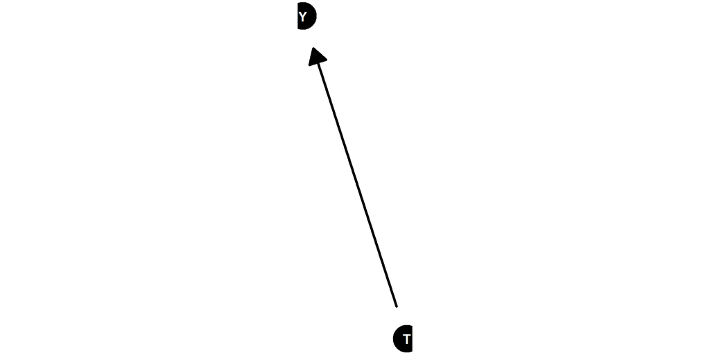

## Adding confounding

TOU adoption is often **opt-in**.

- **C:** “energy preferences” (latent) affects adoption and use.

```r
g2 <- dagitty("dag {
  T [TOU_adopt]
  Y [peak_kwh]
  C [latent]
  C -> T
  C -> Y
  T -> Y}")
ggdag_eefe(g2, label_mode = "name")
```

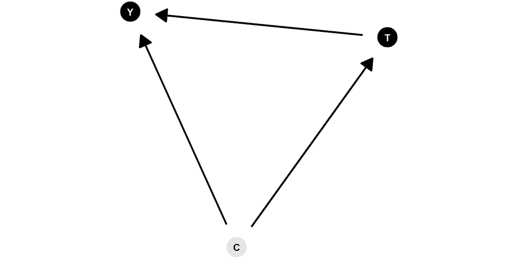

## The real world and omission

A DAG is **not** “everything that matters.”

Goal: include variables that create:

- alternate explanations (back doors)
- channels (front doors)
- biases (colliders)

Rule of thumb: if leaving something out changes your identification story, it belongs.

## “Measurement” vs “causal” nodes

Sometimes we draw:

- **Constructs** (risk preferences, environmental attitudes)
- **Measurements** (survey item, index, proxy)

In DAGs, be explicit about whether a node is the construct or the proxy.

Example: “Environmental concern” vs. “donated to conservation NGO.”

- **Constructs** are usually unobserved/latent
- **Measurements** are observeable variables/data

## Research questions in DAG terms

A useful template:

1. Define the intervention: what is “changing **T**”?
2. Define the estimand: ATE? effect for compliers? short-run? (We’ll get to these later)
3. Translate to: **T → Y** (what blocks spurious paths?)

Environmental example:

- **T:** nitrate regulation stringency
- **Y:** drinking water nitrate concentration
- Create a DAG for this

## Moderators (heterogeneity)

Moderators are variables that change the size/sign of a causal effect.

Energy example:

- TOU effect may differ by **AC ownership**.

You can represent moderation by:

- including the moderator and discussing heterogeneous effects
- or splitting into subgroup DAGs (same structure, different parameters)

# Drawing Causal Diagrams

## From a question to a defensible DAG

### Start with your idea of the world

Causal diagrams formalize what you already believe.

For applied economics, that belief comes from:

- institutional detail (policy rules, market design)
- engineering/biophysical constraints
- prior evidence
- field knowledge (how people respond)

If you can’t defend arrows, you can’t defend identification.

Good identification usually comes from deep knowledge of the rules/policies/incentives/norms of your setting.

## Walk through the DGP

Example: **Effect of irrigation efficiency upgrades on groundwater pumping**

- **T:** upgrade to drip irrigation
- **Y:** groundwater pumping (acre-feet)

Candidate drivers:

- **Crop mix** (perennials vs annuals)
- **Water prices / pumping costs**
- **Weather / drought**
- **Farm management quality** (latent)
- **Policy incentives / cost-share eligibility**

## First-pass DAG (include the obvious)

```r
g3 <- dagitty("dag {
  T [drip_upgrade]
  Y [gw_pumping]
  W [weather]
  P [pumping_cost]
  K [crop_mix]
  Q [latent]
  S [subsidy_elig]

  W -> Y
  P -> Y
  K -> Y

  Q -> T
  Q -> K
  Q -> Y

  S -> T
  S -> K

  T -> K
  T -> Y}")
```

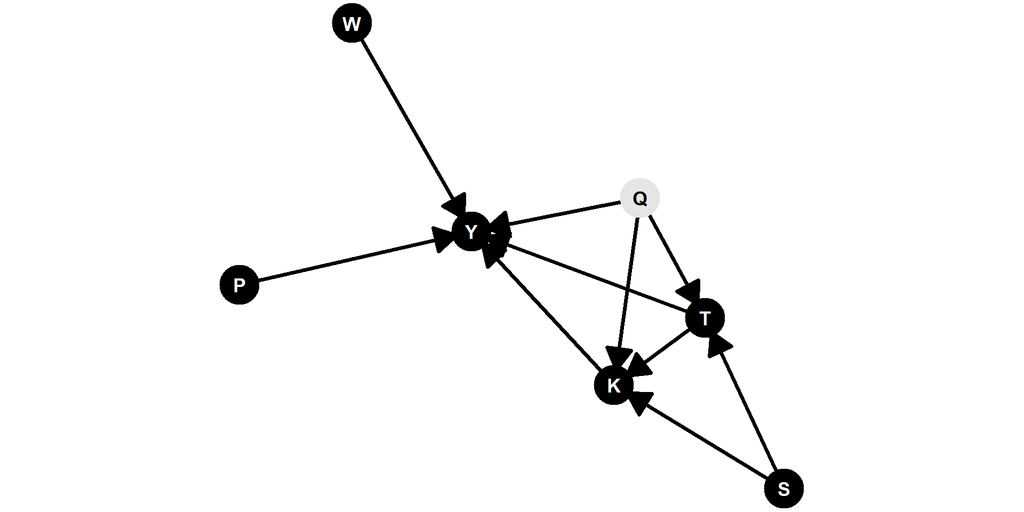

```r
ggdag_eefe(g3)
```

## Interpret the arrows (discipline-specific)

- **T → Y:** efficiency changes marginal cost of water services; could reduce or increase pumping (rebound).
- **Q (latent):** better managers adopt early and also pump differently.
- **S → T:** cost-share programs increase adoption.
- **S → K:** eligibility can alter crop choices (e.g., perennial conversion).

This is the point where you should argue *mechanisms*.

## Simplify without losing the identification story

Simplification strategies:

- combine tightly related variables (e.g., “weather” not 10 climate measures)
- omit variables that only sit on already-blocked paths
- collapse multiple mediators into one “behavioral response” node

But: never simplify away your *hard part* (unmeasured confounding, selection).

## Avoiding cycles

Economics is full of feedback:

- prices affect adoption; adoption affects prices

DAGs are acyclic, so choose a time ordering:

- Use **lagged** versions (e.g., last year’s prices)
- Use a snapshot causal question: “short-run effect holding market fixed”

If feedback is central, consider dynamic models or sequential DAGs.

## Getting comfortable with assumptions

Two “honesty checks”:

- **Missing arrow** is an assumption (“no direct effect”)
- **Missing node** is an assumption (“doesn’t matter for identification”)

Practice: pick one missing arrow in your DAG and write a defense:

- institutional restriction, timing, physics, or strong prior evidence.

# Causal Paths and Closing Back Doors

## Paths explain correlations

A **path** is any route from **T** to **Y** ignoring arrow direction.

Why it matters:

- every open back-door path is an alternate explanation
- your job is to close the bad ones without closing the good ones

## Finding all paths

Example: **effect of solar adoption on monthly electricity bills**

- **T:** rooftop solar adoption
- **Y:** bill amount
- **C:** income
- **R:** roof suitability

```r
g4 <- dagitty("dag {
  T [solar_adopt]
  Y [bill]
  C [income]
  R [roof_suit]

  C -> T
  C -> Y
  R -> T
  R -> Y
  T -> Y}")
```

```r
ggdag_eefe(g4)
```

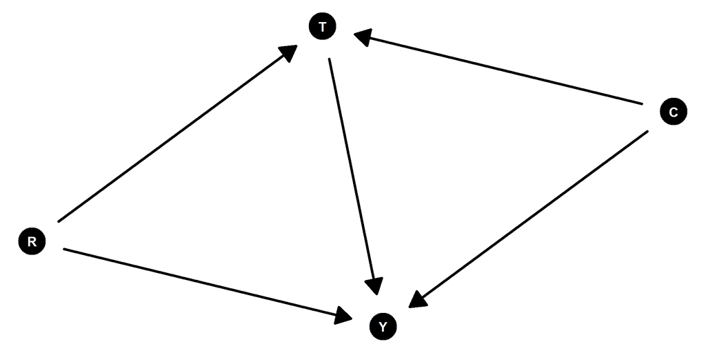

Paths from T to Y:

- T → Y (front door)
- T ← C → Y (back door)
- T ← R → Y (back door)

## Good paths vs bad paths

### Front vs. back doors

- **Front door:** starts with an arrow out of **T**
- **Back door:** starts with an arrow into **T**

Back doors create confounding. Close them by conditioning on appropriate nodes.

How do you “condition” in practice?

In the solar example, conditioning on {Income, Roof suitability} blocks both back doors.

```r
g4 <- dagitty("dag {
  T [solar_adopt]
  Y [bill]
  C [income]
  R [roof_suit]

  C -> T
  C -> Y
  R -> T
  R -> Y
  T -> Y}")

adjustmentSets(g4, exposure = "T", outcome = "Y")
```

```
{ C, R }
```

## Colliders

A **collider** is a variable that is **caused by two (or more) other variables**.

In a causal diagram, it has **two arrows pointing into it**:

X → C ← Y

Here, **C is a collider** because it is a *common effect* of **X** and **Y**.

X does not cause Y on this path and Y does not cause X: **The path is closed.**

### Key idea

- Colliders are **effects**, not causes
- They arise when two processes jointly influence the same outcome
- Examples in applied economics include:
  - Enforcement actions
  - Selection into a program
  - Observed participation or take-up
  - Survey response or sample inclusion

## Why a Collider Closes a Backdoor Path

### Information flow in a DAG

Paths in a DAG represent **potential channels of statistical association**.

Whether a path is *open* or *closed* depends on the structure of the nodes along it.

### Collider rule

A path that passes through a collider is **closed by default**.

T → C ← U → Y

- **C** is a collider on the path from **T** to **Y**
- Because arrows point *into* **C**, information does **not flow through C**
- The backdoor path from **T** to **Y** is therefore **blocked**

### Applied example (environment / energy)

- **T:** emissions regulation stringency
- **Y:** respiratory health outcomes
- **C:** enforcement actions
- **U:** political or community pressure

Enforcement actions occur when **both** regulation is strict **and** pressure is high.

Because enforcement is a collider:

- regulation and pressure are **not associated through C**
- the backdoor path is **closed**

Write out the DAG and all the paths for this example.

### Takeaway

> **Colliders block backdoor paths unless something is done to open them.**

This is why simply identifying a backdoor path is not enough—  
you must also understand **how it is blocked**.

## Open and closed paths

A path is **closed** if it includes:

- a **non-collider** you condition on
- or a **collider** you *do not* condition on (colliders block by default)

A path is **open** if:

- every collider is conditioned on (or has a conditioned descendant), and
- no non-collider on the path is conditioned on.

These rules drive common “bad control” mistakes in regressions.

## Colliders and “Bad Controls” in Econometrics

### Canonical example: education and wages

- **T:** Education
- **Y:** Wages
- **A:** Ability (unobserved)
- **E:** Employment status

### Canonical example: education and wages

Economic structure:

- Education → Wages
- Ability → Wages
- **Employment (E)** is a *collider*: it is a **joint outcome** of education and ability
- Conditioning on employment (or restricting to employed workers) is a **bad control**
- This induces correlation between education and unobserved ability, biasing OLS

> In econometric terms: conditioning on a collider creates **selection bias**

### Econometric takeaway

> Variables that look like “controls” are often **outcomes of selection**.

> In DAG language: many bad controls are **colliders**.

Education → Employment ← Ability

What key assumption is necessary for identification in this setting even when not controlling for Employment?

## Collider Bias

### Example: nutrition education and diet quality

Suppose we want the causal effect of **nutrition education** on **diet quality**.

- **T:** Nutrition education program
- **Y:** Diet quality (e.g., Healthy Eating Index)
- **U:** Health motivation (unobserved)
- **C:** Grocery shopping intensity (e.g., frequency of store visits)

Economic structure:

- Nutrition education → Diet quality
- Health motivation → Diet quality
- Nutrition education → Grocery shopping ← Health motivation
- **Grocery shopping intensity (C)** is a **collider**
- It increases when:
  - people receive nutrition education, **and**
  - people are already highly health-motivated

### Where collider bias enters

Researchers often: - control for grocery shopping behavior, or - restrict samples to “regular shoppers”

But grocery shopping is **not a confounder**:

- it is an **outcome of both treatment and unobserved motivation**

Conditioning on it:

- induces correlation between nutrition education and health motivation
- biases the estimated effect of education on diet quality

### Econometric interpretation

> Controlling for behavior that lies *downstream* of both treatment and preferences converts unobserved heterogeneity into selection bias.

> Behaviors that seem “mechanically related” to outcomes  
> are often **colliders**, not controls.

## Good vs. bad controls

Bad controls often arise from:

- post-treatment variables (mediators)
- colliders (or their descendants)

Before writing a regression, ask:

- Is this control a cause of **T**? (potential confounder)
- Is it caused by **T**? (mediator / post-treatment)
- Is it a collider on some back door?

## Mediation and post-treatment controls

Research question: effect of **emissions enforcement** on **asthma ED visits**

- **T:** enforcement intensity
- **M:** ambient PM2.5
- **Y:** asthma visits
- **C:** neighborhood SES (confounds T and Y)

```r
g6 <- dagitty("dag {
  T [enforcement]
  M [pm25]
  Y [asthma_ed]
  C [ses]

  C -> T
  C -> Y
  C -> M

  T -> M
  M -> Y
  T -> Y}")
ggdag_eefe(g6, layout = "fr") + theme_dag()
```

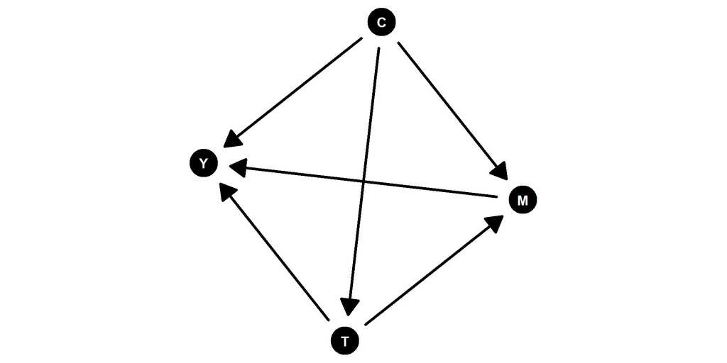

Controlling for **M** gives a *direct effect* of enforcement not mediated by ambient PM2.5, not the total effect.

## Using paths to test your diagram (placebo logic)

DAGs imply **conditional independence**.

Example idea:

- If your DAG claims `Roof suitability ⟂ Soda purchases | Income`, you can test it.

Caveat:

- failures may mean the DAG is wrong, or measurement error, or sample selection
- successes do not prove the DAG is correct

Still useful as a diagnostic and for placebo outcomes/exposures.

## Summary: back-door identification workflow

1. Draw DAG for the question and context
2. List paths from **T** to **Y**
3. Classify: front doors vs back doors
4. Propose adjustment set that blocks all back doors (avoid colliders/post-treatment)
5. Map to estimator (regression, matching, weighting, etc.)

# Finding Front Doors

## Isolate “good variation” or estimate arrows

### Why “close all back doors” can fail

In applied micro, some confounders are:

- unmeasured (preferences, ability, risk tolerance)
- poorly measured (latent constructs)
- endogenous proxies

Front-door thinking asks:

- Can we isolate variation in **T** that avoids key back doors?
- Or can we estimate pieces of the causal chain credibly?

## Isolating “cleaner” variation

Example: effect of **electricity price** on **consumption**

- **T:** retail electricity price
- **Y:** household kWh

Challenge: price is endogenous to demand and policy.

“Front-door” design:

- isolate price shocks from **fuel cost pass-through** or **regulated tariff formula**
- focus on within-utility, time variation driven by exogenous input costs

DAG intuition: use only the portion of **T** driven by a node with no back door to **Y**.

## “What the world can do for us”: design strategies

Common ways to isolate front doors:

- randomized encouragement / audit assignment
- rule-based assignment (eligibility cutoffs, lotteries)
- plausibly exogenous shocks (weather for wind generation; disasters; plant outages)
- institutional formulas (tariff pass-through; cap-and-trade allocations)

Key: argue why the source of variation blocks the problematic back doors.

## Front-door method

Suppose we want the effect of **diesel generator use** (T) on **asthma visits** (Y), but location and behavior create unobserved confounding.

We observe a mediator:

- **M:** near-home PM2.5 (from monitors / low-cost sensors)

Front-door conditions:

1. All causal influence of T on Y goes through M (T → M → Y)
2. No unblocked back door from T to M
3. No unblocked back door from M to Y once conditioning on T

## A front-door-style DAG (illustrative)

```r
g7 <- dagitty("dag {
  T [diesel_use]
  M [pm25_near]
  Y [asthma_ed]
  U [latent]

  T -> M
  M -> Y

  U -> T
  U -> Y
}")
ggdag_eefe(g7)
```

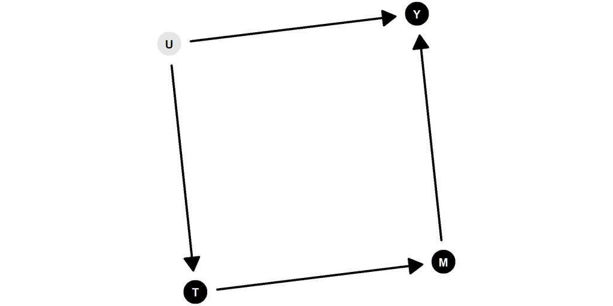

Interpretation: we can’t close U by controls, but we may be able to identify via M if conditions hold.

## Computing front-door quantities (mechanics)

Even when the *total* effect T → Y is confounded, we can estimate:

- Effect of **T on M**
- Effect of **M on Y**, controlling for **T**
- Combine them to recover the overall effect (front-door formula)

In practice, you still need:

- rich measurement of M
- strong assumptions about excluded pathways
- careful robustness checks

## What can go wrong (and how to diagnose)

Common threats in front-door-style applications:

- T affects Y through other channels not captured by M
- unmeasured confounding between T and M (e.g., weather, site selection)
- unmeasured confounding between M and Y (e.g., concurrent health shocks)
- measurement error in M (attenuation / bias in nonlinear settings)

Diagnostics:

- multiple mediators / negative controls
- sensitivity analysis
- pre-trends / placebo timing tests when using shocks

## Practical takeaway for applied papers

Most applied economics work uses:

- **back-door closure** (controls, FE, matching)
- or **front-door isolation** via research design (DiD, IV, RD, lotteries)

Use DAGs to:

- justify the identifying variation
- clarify what must be true for identification
- communicate why certain controls are excluded (post-treatment/colliders)
- anticipate critiques (and preempt them)

## Wrap-up

Problem Set 2:

1. Research abstract + DAG
- Write out research abstract that includes a causal research question
- Write out a DAG (in R or other software)
- List all paths
- List all assumptions
- List two plausible threats and one diagnostic per threat
1. Published paper DAG
- Do the same thing for a paper published in a general interest journal or top field journal
- Identification strategy **cannot** be:
- Difference-in-differences
- Randomized experiment
- Regression discontinuity
- Synthetic control